# Plotting Lines

NOTE: If you are running this on something other than the Raspberry Pi image provided, the libraries may not be installed.

In order to run this exercise, you will need:

- numpy
- matplotlib

If you are having trouble installing these, please feel free to contact me.

You can also just read this section to see what it does before worrying too much about it! The goal is to show how plotting can be used to see how numbers can be represented graphically in python.

```python
%import numpy as np
```

Let's creat a special list using our numpy package.

```python
x=np.arange(6)
print x
```

```
[0 1 2 3 4 5]
```

It's pretty much the same kind of list we have seen before, but we can do interesting things with it, like multiply the entire list by a number:

```python
y=5*x

print 'x: ' + str(x)
print 'y: ' + str(y)
```

```
x: [0 1 2 3 4 5]
y: [ 0  5 10 15 20 25]
```

Can you verify (by hand) that each value of y is correct?

We can also add numbers to it very easily:

```python
b=3

#now we multiply by a number AND add to it!
y=5*x+b

print 'b: '+str(b)
print 'x: ' + str(x)
print 'y: ' + str(y)
```

```
b: 3
x: [0 1 2 3 4 5]
y: [ 3  8 13 18 23 28]
```

This takes a little more work to verify by hand, so maybe only do a couple of them to see if they are correct.

# Plotting your Data!

We have two lists, x, and y, and we can now plot them on a graph to see how they look. Rather than worry about the details of the code, let's just try to run it and look at the output.

At the command line, run

**python plot_line.task1.py 5 4**

The first argument tells python to create x=[0 1 2 3 4 5] The second argument tells python to multiply each element of x by 4.

```python
#remove this for demo
%matplotlib inline
%load plot_line.task1.ipex.py
import sys
sys.argv[1]=5
sys.argv[2]=4
```

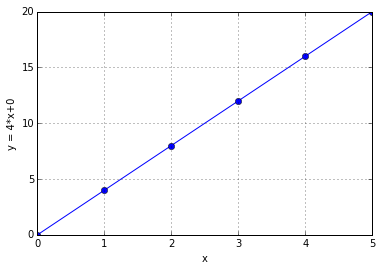

```
x: [0 1 2 3 4 5]
y: [ 0  4  8 12 16 20]
```

```python
# third coding challenge!

# You will learn about:
# - defining numpy ranges
# - multiplying and adding arrays
# - plotting results
# - defining functions

# this is the modification of the original script to have:
# a function called for the value
# b returned

import matplotlib.pyplot as plt
import numpy as np
import sys

b=0
xmax = int(sys.argv[1])
m    = int(sys.argv[2])
if len(sys.argv)==4:
  b    = int(sys.argv[3])


# ++++++++++++++++++++++++++++++++++++++++++++++++++++
# TASK 1:
# - using xmax as the maximum value, create an array of
#   values from 0 to xmax.
# - multiply all of those values by m
# - review the results with the teacher.
# ++++++++++++++++++++++++++++++++++++++++++++++++++++

x=np.arange(xmax+1)
y=m*x+b

# ++++++++++++++++++++++++++++++++++++++++++++++++++++
# TASK 2:
# - write a function line(m,x,b) that will multiply
#   all values by m and add b... ( ie: y=m*x+b )
# ++++++++++++++++++++++++++++++++++++++++++++++++++++


# ++++++++++++++++++++++++++++++++++++++++++++++++++++
# TASK 3 (optional):
# - what about another equation, like y=m*x*x + b?
# - what if x went from -xmax to xmax instead of 0 to xmax?
# ++++++++++++++++++++++++++++++++++++++++++++++++++++
#



plt.plot(x,y,'-o')
plt.grid()

plt.xlabel('x')
plt.ylabel('y = '+ str(m) +'*x'+'+'+str(b))
plt.show()

print "x: "+str(x)
print "y: "+str(y)


#import rlcompleter; import readline; readline.parse_and_bind("tab: complete")
#import code; code.interact(local=locals())
```

If not, no big deal...just follow along here!

We see that x and y are computed, and that each value of y comes from multiplying that element by 4. Looking at the plot, you can look at the circles, and see that when x=1, y=4. Allo of the points on the graph are plotted in this way. Can you verify this?

Maybe you already knew this, but look how the points make a straight line! Cool!